# 2.2 Doing it Bayesian

19/01/2025

## Frequentist statistics

Data are probabilistic!

How probable it is to get these interesting data if nothing interesting is going on?

\[p\ value = P(data|null \ hypothesis)\]

Improbable? Something interesting is going on!

## Frequentist statistics

Data are probabilistic!

How probable are the data given hypothesis x? How likely is the hypothesis x given the data?

\[L(hypothesis \ x|data) = P(data|hypothesis\ x)\]

Lets find the most likely hypothesis based on the data!

## Bayesian statistics

Hypotheses are also probabilistic! How probable are different hypotheses based on data?

\[P(hypothesis|data)\]

(We use here probability as a measure of belief.)

## A bit of algebra again

Rule for joint (AND) probability is \[P(A \cap B) = P(A) \times P(B|A)\] \(A\) and \(B\) can be swapped arbitrarily \[P(A \cap B) = P(B) \times P(A|B)\]

## A bit of algebra again

and so \[P(B) \times P(A|B) = P(A) \times P(B|A)\] which we can rearrange to get \[P(A|B) = \frac {P(B|A) \times P(A)}{P(B)}\] which is **the Bayes rule**.

## Conditional probability

We can also say that \[P(B)=P(B|A) \times P(A)+P(B|nonA) \times P(nonA)\] so \[P(A|B) =\frac {P(B|A) \times P(A)}{P(B)}\]

\[=\frac {P(B|A) \times P(A)}{P(B|A) \times P(A)+P(B|nonA) \times P(nonA)}\]

## Conditional probability

if we use sum sign \[P(A|B)=\frac {P(B|A) \times P(A)}{\sum_A P(B|A) \times P(A)}\]

## Bayes rule in statistics

we can replace \(A\) and \(B\) by model parameters \(\theta\) (or \(H\)) and the data \(x\) (or \(d\)) to get

\[p(\theta|x) = \frac {p(\theta) \times p(x|\theta)}{p(x)}\]

where

\(p(x|\theta)\) … likelihood

\(p(\theta)\) … prior

\(p(\theta|x)\) … posterior

\(p(x)\) … the horrible thing

## Why is p(x) horrible?

\[p(x)=\sum_\theta p(\theta) \times p(x|\theta)\]

\[p(x)=\int_\theta p(\theta) \times p(x|\theta) d\theta\]

## The data

We have five data points from poisson distribution

```r
x=rpois(5,20)
x
```

```
## [1] 16 16 20 26 24
```

We would like to know posterior distribution of \(\lambda\)

## Analytical solution

Poisson distribution posterior can be expressed as

\[p(\lambda|x)=\dfrac{p(x|\lambda)*p(\lambda)}{p(x)}\]

where

\[p(x|\lambda)=\prod\limits_{i=1}^n \dfrac{\lambda^{x_i}e^{-\lambda}}{x_i!}; p(\lambda)=0.01\\\]

\[p(x)=\int_\lambda (\prod\limits_{i=1}^n \dfrac{\lambda^{x_i}e^{-\lambda}}{x_i!}*0.01) d\lambda\\ \]

## Analytical solution - properties

- is accurate
- cannot be obtained for most model types

## Numerical computation

We can try to compute numerically

The numerator can be expressed as R function

```r
baypo=function(l){
  #likelihood
  lh=function(l){
    prod(((l^x)*exp(-l))/factorial(x))
  }
  #likelihood and prior
  100000000*lh(l)*dunif(l,0,100)
  }
```

## Numerical computation

Now we can generate a grid (or whatever else) and feed the function

```r
lambda=seq(0,100,0.01)
postdist=NULL
for (i in 1:length(lambda)){
  postdist[i]=baypo(lambda[i])
  }
prob=postdist/sum(postdist)
```

## Numerical computation

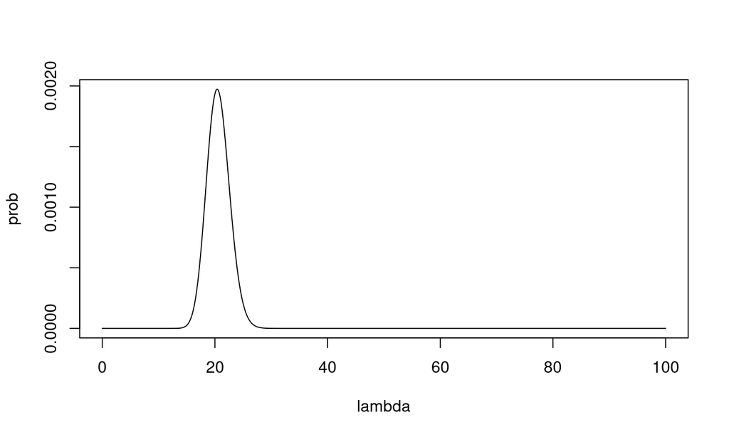

```r
plot(prob~lambda, type="l")
```

## Numerical computation - properties

- is terribly slow and wasteful
- theoretically works always
- can be paralelized on clusters